# Vector Autoregressions

Natasha Kang

Xiamen University, Chow Institute

March, 2026

# VAR Motivation and Structure

## Recall: ADL Models

We have studied dynamic relationships using autoregressive distributed lag (ADL) models.

$$y_t
=
\alpha
+
\sum_{j=1}^p \phi_j y_{t-j}
+
\sum_{k=0}^q \beta_k x_{t-k}
+
u_t.$$

The model captures:

- persistence (lags of $y_t$)
- dynamic effects of $x_t$ through its lags
- gradual adjustment over time

But they rely on an important **modeling assumption**.

For consistent estimation and interpretation:

- the regressors must be weakly exogenous
- feedback from $y_t$ to $x_t$ is ruled out

This assumption is often implicit, but it is essential. In many macroeconomic settings, however:

- policy reacts to economic conditions
- variables evolve jointly
- feedback is pervasive

## A Simple Control-System Analogy

Consider a thermostat regulating room temperature:

- $y_t$: room temperature
- $x_t$: thermostat setting
- $u_t$: unobserved temperature shocks (weather, insulation, people entering the room)

The thermostat follows a rule: it adjusts the setting in response to past temperature outcomes.

For example,
$$x_t = \gamma (y_{t-1} - y^\ast),$$
where $y^\ast$ is the target temperature.

Room temperature evolves as:
$$y_t = \alpha y_{t-1} + \beta x_t + u_t.$$

Because $x_t$ is constructed as a function of past outcomes, and past outcomes depend on past shocks, we have:

$$\mathrm{Cov}(x_t, u_{t-1}) \neq 0.$$

Exogeneity fails **because** policy responds to the state of the system.

## Large-Scale Macroeconometric Models

Historically, macroeconomists modeled the economy using large-scale macroeconometric models.

These models:

- consist of many simultaneous equations
- specify behavioral relationships for each variable (e.g. consumption, investment, etc.)
- explicitly allow feedback across the system

For example, a model might include equations such as:
$$\begin{aligned}
C_t &= f(Y_t, T_t, W_{t-1}, C_{t-1}) \\
I_t &= g(Y_t, r_t, I_{t-1}) \\
M_t &= h(Y_t, P_t, M_{t-1})
\end{aligned}$$

This structure creates several difficulties:

- if a variable appears on the right-hand side of one equation (e.g. $r_t$ in the investment equation), it is unclear why it is excluded from others
- differences in regressors across equations are not disciplined by economic theory, but imposed through ad hoc modeling choices
- exclusion and lag restrictions that appear reasonable within individual equations (e.g. allowing $r_t$ to affect $I_t$ but not $C_t$) imply strong system-wide restrictions once the equations are linked

## Symmetric Dynamic System

When it is not clear which variables are exogenous, a natural modeling choice is to treat all variables symmetrically.

For example, consider a simple bivariate system

$$\begin{aligned}
y_t &= b_{10} - b_{12} z_t
+ \gamma_{11} y_{t-1}
+ \gamma_{12} z_{t-1}
+ \varepsilon_{yt}, \\
z_t &= b_{20} - b_{21} y_t
+ \gamma_{21} y_{t-1}
+ \gamma_{22} z_{t-1}
+ \varepsilon_{zt}.
\end{aligned}$$

Let
$$x_t =
\begin{bmatrix}
y_t \\ z_t
\end{bmatrix},
\qquad
\varepsilon_t =
\begin{bmatrix}
\varepsilon_{yt} \\ \varepsilon_{zt}
\end{bmatrix}.$$

The system can be written compactly as
$$B x_t = \Gamma_0 + \Gamma_1 x_{t-1} + \varepsilon_t,$$
where

$$B =
\begin{bmatrix}
1 & b_{12} \\
b_{21} & 1
\end{bmatrix},
\qquad
\Gamma_0 =
\begin{bmatrix}
b_{10} \\
b_{20}
\end{bmatrix},
\qquad
\Gamma_1 =
\begin{bmatrix}
\gamma_{11} & \gamma_{12} \\
\gamma_{21} & \gamma_{22}
\end{bmatrix}.$$

# Structural and Reduced Form

## Structural Restrictions and Reduced Form

The matrix $B$ summarizes **contemporaneous structural restrictions**.

If $B$ is invertible, the system implies a reduced-form representation:
$$x_t = A_0 + A_1 x_{t-1} + u_t,
\qquad
u_t = B^{-1}\varepsilon_t.$$

The reduced form is **invariant** to the choice of contemporaneous structural restrictions, and can be estimated by OLS.

> Sims (1980) proposed estimating this reduced form directly, arguing that many structural models relied on “incredible restrictions.”

## Stability and Stationarity

Consider the VAR(1):
$$x_t = A_0 + A_1 x_{t-1} + u_t.$$

Iterating backward,
$$x_t
=
\Big(\sum_{i=0}^{k} A_1^i\Big) A_0
+
\sum_{i=0}^{k} A_1^i u_{t-i}
+
A_1^{k+1} x_{t-k-1}.$$

**Stability condition:** all eigenvalues of $A_1$ lie strictly inside the unit circle.

### Consequences of Stability

If all eigenvalues of $A_1$ lie strictly inside the unit circle, then:

- $A_1^{k+1} x_{t-k-1} \to 0$ as $k \to \infty$ (the effect of initial conditions vanishes)
- The series $\sum_{i=0}^{\infty} A_1^i u_{t-i}$ converges in mean square
- $\sum_{i=0}^{\infty} A_1^i = (I-A_1)^{-1}$

Hence, the stationary solution is
$$x_t = \mu + \sum_{i=0}^{\infty} A_1^i u_{t-i},
\qquad
\mu = (I-A_1)^{-1}A_0.$$

Equivalently, the MA($\infty$) representation can be written using lag operators as
$$x_t - \mu = (I-A_1L)^{-1} u_t.$$

Under the stability condition, $\{x_t\}$ is covariance-stationary.

# VAR($p$) and Stability

## Generalization to VAR($p$)

Consider the VAR($p$):
$$x_t = A_1 x_{t-1} + \cdots + A_p x_{t-p} + u_t.$$

Define the stacked state vector
$$X_t =
\begin{bmatrix}
x_t \\ x_{t-1} \\ \vdots \\ x_{t-p+1}
\end{bmatrix},$$
so the system can be written in **companion form**
$$X_t = \mathscr{A} X_{t-1} + \mathscr{U}_t,$$
where
$$\mathscr{A}
=
\begin{bmatrix}
A_1 & A_2 & \cdots & A_p \\
I & 0 & \cdots & 0 \\
& \ddots & \ddots & \vdots \\
0 & & I & 0
\end{bmatrix}.$$

The VAR($p$) is **stable** if all eigenvalues of the companion matrix $\mathscr{A}$ lie strictly inside the unit circle:

$$\det\!\big(I - A_1 z - \cdots - A_p z^p\big) \neq 0
\quad \text{for } |z| \le 1.$$

# Forecasting in VARs

## Forecasting in VAR Models

Under stability, the VAR($p$) admits the MA($\infty$) representation
$$x_t = \mu + \sum_{j=0}^{\infty} \Psi_j u_{t-j},$$
and the process is causal.

Because future shocks have zero conditional mean, the $h$-step-ahead forecast based on information at time $t$ is
$$\widehat{x}_{t+h|t} \equiv \mathbb{E}_t[x_{t+h}]
=
\mu + \sum_{j=h}^{\infty} \Psi_j u_{t+h-j}.$$

In practice, forecasts are computed **recursively from the VAR**.

The one-step-ahead forecast is
$$\widehat{x}_{t+1|t}
=
A_1 x_t + \cdots + A_p x_{t-p+1}.$$

Multi-step forecasts satisfy
$$\widehat{x}_{t+h|t}
=
A_1 \widehat{x}_{t+h-1|t}
+ \cdots
+ A_p \widehat{x}_{t+h-p|t},
\qquad h \ge 1.$$

## Forecast Error Variance

From the MA($\infty$) representation,
$$x_t = \mu + \sum_{j=0}^{\infty} \Psi_j u_{t-j},$$
the $h$-step-ahead forecast error is
$$x_{t+h} - \widehat{x}_{t+h|t}
=
\sum_{j=0}^{h-1} \Psi_j u_{t+h-j}.$$

Let $\Sigma_u = \mathrm{Var}(u_t)$. The $h$-step-ahead forecast error variance is
$$\mathrm{Var}_t\!\big(x_{t+h}-\widehat{x}_{t+h|t}\big)
=
\sum_{j=0}^{h-1} \Psi_j \Sigma_u \Psi_j'.$$

Under stability, this variance increases with $h$ but converges to the unconditional variance of $x_t$.

### confidence intervals

Under Gaussian (or asymptotic normality) assumptions,
$$x_{t+h} \mid \mathscr{F}_t
\;\sim \;
N\!\left(
\widehat{x}_{t+h|t},
\;\mathrm{Var}_t(x_{t+h})
\right).$$
**conditional on the estimated VAR parameters**.

This distribution accounts for uncertainty from future shocks, but **ignores parameter estimation uncertainty**.

For component $i$ of $x_{t+h}$, a $100(1-\alpha)\%$ forecast confidence interval is
$$\widehat{x}_{i,t+h|t}
\;\pm\;
z_{1-\alpha/2}
\sqrt{
\left[\mathrm{Var}_t(x_{t+h})\right]_{ii}
}.$$

## Computing Forecast Error Variance in Practice

### VAR(1): recursion you can compute directly

Suppose
$$x_t = A_0 + A x_{t-1} + u_t,
\qquad
\mathrm{Var}(u_t)=\Sigma_u.$$

Let the $h$-step forecast error be
$$e_{t+h|t} \equiv x_{t+h} - \widehat x_{t+h|t}.$$

Then
$$e_{t+1|t}=u_{t+1},
\qquad
e_{t+h|t}=A\,e_{t+h-1|t}+u_{t+h}\quad (h\ge2).$$

Taking conditional variances gives the recursion
$$\Omega_1 = \Sigma_u,
\qquad
\Omega_h = A\,\Omega_{h-1}A' + \Sigma_u,
\qquad
\Omega_h \equiv \mathrm{Var}_t(e_{t+h|t}).$$

### VAR($p$): same idea via the companion form

Write the VAR($p$) in companion form
$$X_t = \mathscr{A}X_{t-1}+\mathscr{U}_t,
\qquad
\mathscr{U}_t=
\begin{bmatrix}
u_t\\ 0\\ \vdots\\ 0
\end{bmatrix},
\qquad
\mathrm{Var}(\mathscr{U}_t)=
\mathscr{\Sigma}_{\mathscr{U}}=
\begin{bmatrix}
\Sigma_u & 0\\
0 & 0
\end{bmatrix}.$$

Let $\Omega_h^X \equiv \mathrm{Var}_t(X_{t+h}-\widehat X_{t+h|t})$. Then
$$\Omega_1^X=\mathscr{\Sigma}_{\mathscr{U}},
\qquad
\Omega_h^X=\mathscr{A}\,\Omega_{h-1}^X\,\mathscr{A}'+\mathscr{\Sigma}_{\mathscr{U}}.$$

The forecast error variance for $x_{t+h}$ (the first $K$ components of $X_{t+h}$) is
$$\Omega_h
=
J\,\Omega_h^X\,J',
\qquad
J=\begin{bmatrix} I_K & 0 & \cdots & 0 \end{bmatrix}.$$

## Example: Forecasting in a Stable VAR (Simulated Data)

We simulate a stable bivariate VAR(1) process and illustrate multi-step forecasts and forecast confidence intervals.

- Data-generating process is stationary by construction
- Forecasts are produced recursively from the VAR
- Confidence intervals reflect uncertainty from future shocks

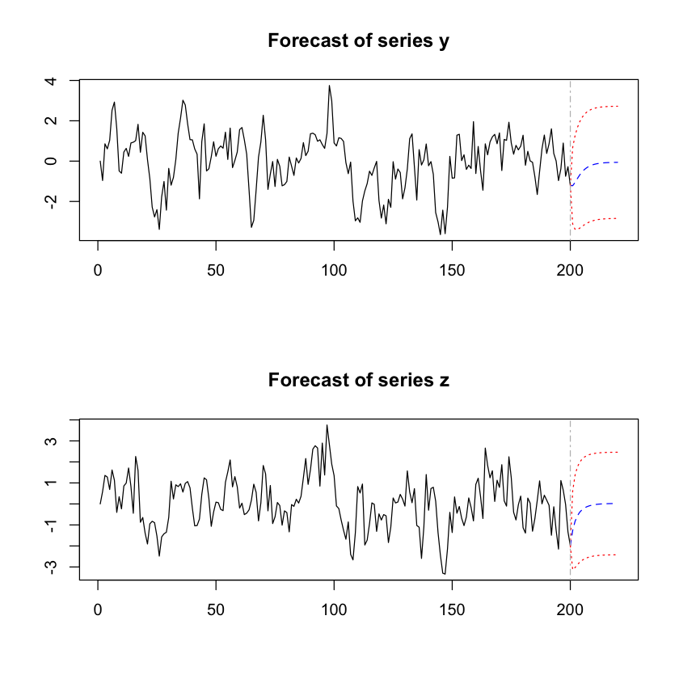

## Dimensionality in VAR Models

Consider the reduced-form VAR($p$):
$$x_t = A_1 x_{t-1} + \cdots + A_p x_{t-p} + u_t,
\qquad
\mathrm{Var}(u_t)=\Sigma_u.$$

Let $K$ be the number of variables.

A VAR($p$) contains
$$K^2 p + K$$
parameters to estimate.

### Consequences

- parameter dimension grows **quadratically** in $K$: **curse of dimensionality**
- increasing lag length rapidly exhausts degrees of freedom
- finite-sample estimation error can be substantial

### Rule of Thumb

Each equation in a VAR($p$) involves approximately $Kp$ slope coefficients.

Empirical practice typically requires
$$T \gtrsim 5\text{–}10 \times Kp$$
for reliable estimation.

As a result, standard VARs are usually restricted to small systems in macroeconomic applications.

# Estimation and Inference

## Estimation and Inference of VAR Models

A VAR($p$) is estimated as a system of linear projections:
$$x_t = A_1 x_{t-1} + \cdots + A_p x_{t-p} + u_t.$$

Estimation is typically carried out by equation-by-equation ordinary least squares.

### Inference

If:

- the VAR is stable, so $\{x_t\}$ is stationary
- the reduced-form specification is correct (innovations are orthogonal to lagged regressors)
- the dimension $(K,p)$ is fixed relative to sample size $T$

then:

- OLS estimators are consistent
- standard asymptotic theory applies

## What If the Variables Are Nonstationary?

In macroeconomic applications, many variables exhibit **stochastic trends**:

- output, consumption, investment
- prices, money, credit aggregates

A natural response is to difference the data:
$$\Delta x_t = x_t - x_{t-1}.$$

This guarantees stationarity and allows a VAR to be estimated in differences.

However, differencing is not innocuous.

- If variables share common stochastic trends, differencing removes **long-run relationships**.
- As a result, a VAR in differences cannot capture equilibrium comovement in the data.

(Sims, Stock, and Watson, 1990)

# Nonstationarity and VECM

## Cointegration and the VECM

Start from a VAR($p$) in levels:
$$x_t = A_1 x_{t-1} + \cdots + A_p x_{t-p} + u_t.$$

Subtract $x_{t-1}$ from both sides:
$$\Delta x_t
=
\Big(A_1 + \cdots + A_p - I\Big)x_{t-1}
+
\sum_{i=1}^{p-1}
\Big(-A_{i+1}-\cdots-A_p\Big)\Delta x_{t-i}
+
u_t.$$

Define
$$\Pi := \sum_{i=1}^p A_i - I,
\qquad
\Gamma_i := -\sum_{j=i+1}^p A_j.$$

Then the VAR can always be written as
$$\Delta x_t
=
\Pi x_{t-1}
+
\sum_{i=1}^{p-1} \Gamma_i \Delta x_{t-i}
+
u_t.$$

Suppose $x_t$ is $I(1)$ and **cointegrated** with rank $r<K$. That is, there exists $\beta \in \mathbb{R}^{K\times r}$ such that
$$\beta' x_t \ \text{is stationary}.$$

In the VECM form,
$$\Delta x_t
=
\Pi x_{t-1}
+
\sum_{i=1}^{p-1} \Gamma_i \Delta x_{t-i}
+
u_t,$$
the left-hand side is stationary, as are $\Delta x_{t-i}$ and $u_t$. Hence $\Pi x_{t-1}$ must be stationary.

Since $x_{t-1}$ is nonstationary, $\Pi x_{t-1}$ can be stationary only if it is a **linear combination** of $\beta' x_{t-1}$.

Equivalently,
$$\mathrm{rank}(\Pi)=r<K
\quad\Rightarrow\quad
\Pi=\alpha\beta'.$$

This yields the **vector error-correction model (VECM)**:
$$\Delta x_t
=
\alpha \beta' x_{t-1}
+
\sum_{i=1}^{p-1} \Gamma_i \Delta x_{t-i}
+
u_t.$$

- short-run dynamics: $\Gamma_i \Delta x_{t-i}$
- long-run equilibrium errors: $\beta' x_{t-1}$
- adjustment back to equilibrium: $\alpha \in \mathbb{R}^{K \times r}$

## Bivariate Example

Let
$$x_t =
\begin{bmatrix}
y_t \\ z_t
\end{bmatrix},
\qquad
y_t,\; z_t \text{ are } I(1).$$

Suppose there exists a scalar $\theta$ such that
$$\beta' x_t = y_t - \theta z_t
\quad \text{is stationary},
\qquad
\beta'=(1,\,-\theta).$$

Then $y_t$ and $z_t$ are **cointegrated** (rank $r=1$).

Define the equilibrium error
$$e_{t-1} \equiv y_{t-1} - \theta z_{t-1}.$$

The VECM
$$\Delta x_t
=
\alpha e_{t-1}
+
\sum_{i=1}^{p-1}\Gamma_i \Delta x_{t-i}
+
u_t,
\qquad
\alpha \in \mathbb{R}^{2\times 1},$$
**implies two error-correction equations**:
$$\begin{aligned}
\Delta y_t &= \alpha_1 e_{t-1} + \text{short-run dynamics} + u_{1t}, \\
\Delta z_t &= \alpha_2 e_{t-1} + \text{short-run dynamics} + u_{2t}.
\end{aligned}$$

## Estimation of the VECM Parameters

Consider the VECM
$$\Delta x_t
=
\Pi x_{t-1}
+
\sum_{i=1}^{p-1}\Gamma_i \Delta x_{t-i}
+
u_t,
\qquad
\Pi=\alpha\beta',
\qquad
\mathrm{rank}(\Pi)=r.$$

### What Needs to Be Estimated

- the short-run parameters $\Gamma_i$
- the long-run matrix $\Pi$, subject to a **rank restriction** $\mathrm{rank}(\Pi)=r<K$

### Implication for Estimation

- ordinary least squares treats $\Pi$ as unrestricted
- unrestricted OLS produces a full-rank estimate of $\Pi$

Therefore, the VECM **cannot be estimated by OLS**.

# Johansen Approach

## Johansen’s Approach (Partial Out)

Start from the VECM:
$$\Delta x_t=\Pi x_{t-1}+\sum_{i=1}^{p-1}\Gamma_i \Delta x_{t-i}+u_t.$$

**Idea:** partial out short‑run dynamics so the remaining relation is purely long‑run.

Regress $\Delta x_t$ and $x_{t-1}$ on $\{\Delta x_{t-1},\dots,\Delta x_{t-p+1}\}$ and keep residuals:
$$\begin{aligned}
R_{0t} &= \Delta x_t - \mathbb{E}[\Delta x_t \mid \Delta x_{t-1},\dots,\Delta x_{t-p+1}],\\
R_{1t} &= x_{t-1} - \mathbb{E}[x_{t-1} \mid \Delta x_{t-1},\dots,\Delta x_{t-p+1}].
\end{aligned}$$

Then the model becomes the **long‑run regression**
$$R_{0t}=\Pi R_{1t}+u_t.$$

This follows from the **Frisch-Waugh-Lovell Theorem**. After partialling out, we isolate the cointegrating relationship.

## Johansen’s Approach (From Long‑Run Regression to Eigenvalues)

Start from the reduced‑rank least‑squares objective:
$$\min_{\mathrm{rank}(\Pi)=r}
\frac{1}{T}\sum_{t=1}^T
(R_{0t}-\Pi R_{1t})'(R_{0t}-\Pi R_{1t}).$$

Expand the quadratic form:
$$\frac{1}{T}\sum_{t=1}^T
\Big(
R_{0t}'R_{0t}
- R_{0t}'\Pi R_{1t}
- R_{1t}'\Pi' R_{0t}
+ R_{1t}'\Pi'\Pi R_{1t}
\Big).$$

Use trace identities: $\mathrm{tr}(x'Ay)=\mathrm{tr}(A y x')$, $\mathrm{tr}(X)=\mathrm{tr}(X')$, and $S_{ij}=\frac{1}{T}\sum_{t=1}^T R_{it}R_{jt}'$:
$$\frac{1}{T}\sum R_{0t}'R_{0t}=\mathrm{tr}(S_{00}),\qquad
\frac{1}{T}\sum R_{0t}'\Pi R_{1t}=\mathrm{tr}(\Pi S_{10}),$$
$$\frac{1}{T}\sum R_{1t}'\Pi'R_{0t}=\mathrm{tr}(S_{01}\Pi'),\qquad
\frac{1}{T}\sum R_{1t}'\Pi'\Pi R_{1t}=\mathrm{tr}(\Pi S_{11}\Pi').$$

The objective is equivalent to
$$\min_{\mathrm{rank}(\Pi)=r}
\mathrm{tr}\!\left(
S_{00}-\Pi S_{10}-S_{01}\Pi' + \Pi S_{11}\Pi'
\right).$$

### Derivation (why the eigenvalue problem appears)

We start from the trace objective
$$J(\Pi)=\mathrm{tr}\!\left(
S_{00}-\Pi S_{10}-S_{01}\Pi'+\Pi S_{11}\Pi'
\right),
\quad S_{ij}=\frac{1}{T}\sum_{t=1}^T R_{it}R_{jt}'.$$

Impose the rank restriction $\Pi=\alpha\beta'$ with $\alpha,\beta\in\mathbb{R}^{K\times r}$. Substitute:

$$J(\alpha,\beta)
=
\mathrm{tr}(S_{00})
-\mathrm{tr}(\alpha\beta' S_{10})
-\mathrm{tr}(S_{01}\beta\alpha')
+\mathrm{tr}(\alpha\beta' S_{11}\beta\alpha').$$

**Rules (matrix differentials):**

- $\mathrm{d}\,\mathrm{tr}(A X)=\mathrm{tr}(A\,\mathrm{d}X)$
- $\mathrm{d}\,\mathrm{tr}(X A X')=\mathrm{tr}\!\big((XA'+XA)\,\mathrm{d}X'\big)$. If $A$ is symmetric, this is $2\,\mathrm{tr}(X A\,\mathrm{d}X')$.

### Step 1: Differentiate w.r.t. $\alpha$ (holding $\beta$ fixed)

Use cyclicity to group $\alpha$:
$$J(\alpha,\beta)=
\mathrm{tr}(S_{00})
-2\,\mathrm{tr}(\alpha\beta' S_{10})
+\mathrm{tr}\!\big(\alpha(\beta' S_{11}\beta)\alpha'\big).$$

Let $B=\beta' S_{11}\beta$ (this is $r\times r$ and symmetric). Then
$$\mathrm{d}J
=
-2\,\mathrm{tr}(\beta' S_{10}\,\mathrm{d}\alpha)
+2\,\mathrm{tr}(\alpha B\,\mathrm{d}\alpha').$$

Convert the second term using $\mathrm{tr}(M\,\mathrm{d}\alpha')=\mathrm{tr}(M'\,\mathrm{d}\alpha)$:
$$\mathrm{d}J
=
-2\,\mathrm{tr}(\beta' S_{10}\,\mathrm{d}\alpha)
+2\,\mathrm{tr}((\alpha B)'\,\mathrm{d}\alpha).$$

Set $\mathrm{d}J=0$ for all $\mathrm{d}\alpha$:
$$-(\beta' S_{10}) + (\alpha B)'=0
\quad\Rightarrow\quad
\alpha B = S_{01}\beta.$$

So
$$\widehat{\alpha}=S_{01}\beta(\beta' S_{11}\beta)^{-1}.$$

### Step 2: Plug back to get a problem in $\beta$ only

Substitute $\widehat{\alpha}$ into $J(\alpha,\beta)$ and simplify:
$$J(\beta)
=
\mathrm{tr}(S_{00})
-
\mathrm{tr}\!\Big[
(\beta' S_{10} S_{00}^{-1} S_{01}\beta)
(\beta' S_{11}\beta)^{-1}
\Big].$$

Thus maximizing the fit is equivalent to
$$\max_{\beta}\;
\mathrm{tr}\!\Big[
(\beta' S_{10} S_{00}^{-1} S_{01}\beta)
(\beta' S_{11}\beta)^{-1}
\Big].$$

Let $A=S_{10}S_{00}^{-1}S_{01}$.
Normalize $\beta'S_{11}\beta=I_r$ and solve
$$\max_{\beta}\ \mathrm{tr}(\beta' A \beta)
\quad \text{s.t.}\quad \beta' S_{11} \beta = I_r.$$

Lagrangian:
$$\mathscr{L}(\beta,\Lambda)
=
\mathrm{tr}(\beta' A \beta)
-
\mathrm{tr}\!\big[\Lambda(\beta' S_{11} \beta - I_r)\big].$$

FOC w.r.t. $\beta$:
$$2A\beta-2S_{11}\beta\Lambda=0
\quad\Rightarrow\quad
A\beta=S_{11}\beta\Lambda.$$

Thus each column $v$ of $\beta$ satisfies
$$A v=\lambda S_{11} v,
\quad\text{i.e.}\quad
S_{10}S_{00}^{-1}S_{01}v=\lambda S_{11}v.$$

### Step 3: Eigenvalue characterization

This is a canonical‑correlation problem. The FOCs imply:
$$S_{10}S_{00}^{-1}S_{01}v=\lambda S_{11}v.$$

Since $S_{11}$ is invertible, multiply by $S_{11}^{-1}$:
$$S_{11}^{-1}S_{10}S_{00}^{-1}S_{01}v=\lambda v.$$

So $v$ is an eigenvector of $S_{11}^{-1}S_{10}S_{00}^{-1}S_{01}$.

The top $r$ eigenvectors $v$ give $\widehat{\beta}$, and $\widehat{\alpha}=S_{01}\widehat{\beta}$.

## Johansen’s Approach (Gaussian MLE Setup)

Assume the VECM errors are Gaussian:
$$u_t \sim N(0,\Sigma_u), \quad t=1,\dots,T.$$

After partialling out short‑run dynamics we have
$$R_{0t}=\Pi R_{1t}+\varepsilon_t,$$
where
$$\varepsilon_t
=
u_t-\mathbb{E}[u_t\mid \Delta x_{t-1},\dots,\Delta x_{t-p+1}],$$
so $\varepsilon_t$ is the **residualized error**.

Under Gaussianity, $\varepsilon_t \sim N(0,\Sigma_\varepsilon)$. The (conditional) log‑likelihood is
$$\ell(\Pi,\Sigma_\varepsilon)
=
-\frac{T}{2}\log|\Sigma_\varepsilon|
-\frac{1}{2}\sum_{t=1}^T
(R_{0t}-\Pi R_{1t})'\Sigma_\varepsilon^{-1}(R_{0t}-\Pi R_{1t})
+ \text{const}.$$

**Key point:** maximizing the likelihood is equivalent to minimizing the weighted sum of squared residuals.

## Johansen’s Approach (Profile Likelihood)

Let $e_t=R_{0t}-\Pi R_{1t}$ and $E=[e_1,\dots,e_T]$. Then $\sum_{t=1}^T e_t e_t' = EE'$.

The Gaussian log‑likelihood is
$$\ell(\Pi,\Sigma_\varepsilon)
=
-\frac{T}{2}\log|\Sigma_\varepsilon|
-\frac{1}{2}\mathrm{tr}(\Sigma_\varepsilon^{-1}EE')
+\text{const}.$$

For fixed $\Pi$, maximize over $\Sigma_\varepsilon$:
$$\widehat{\Sigma}_\varepsilon(\Pi)=\frac{1}{T}EE'.$$

Plug in:
$$\ell(\Pi)
=
-\frac{T}{2}\log\!\left|\widehat{\Sigma}_\varepsilon(\Pi)\right|
-\frac{1}{2}\mathrm{tr}\!\left(\widehat{\Sigma}_\varepsilon^{-1}EE'\right)
+ \text{const}.$$

But
$$\mathrm{tr}\!\left(\widehat{\Sigma}_\varepsilon^{-1}EE'\right)
=
\mathrm{tr}\!\left(\left(\tfrac{1}{T}EE'\right)^{-1}EE'\right)
=
\mathrm{tr}(T I_K)
= TK,$$
which is constant in $\Pi$.

Therefore
$$\ell(\Pi)
=
-\frac{T}{2}\log\!\left|\widehat{\Sigma}_\varepsilon(\Pi)\right|
+ \text{const}.$$

Thus,
$$\max_{\Pi:\,\mathrm{rank}(\Pi)=r}\ \ell(\Pi)
\quad\Longleftrightarrow\quad
\min_{\Pi:\,\mathrm{rank}(\Pi)=r}\ \left|\widehat{\Sigma}_\varepsilon(\Pi)\right|.$$

Start from the profile likelihood:
$$\ell(\Pi)\propto -\frac{T}{2}\log\left|\widehat\Sigma_\varepsilon(\Pi)\right|,
\quad
\widehat\Sigma_\varepsilon(\Pi)
=
S_{00}-\Pi S_{10}-S_{01}\Pi'+\Pi S_{11}\Pi'.$$

Impose $\Pi=\alpha\beta'$ (rank $r$). Let $C=S_{01}\beta$ and $B=\beta'S_{11}\beta$. Then
$$\widehat\Sigma_\varepsilon(\alpha,\beta)
=
S_{00}-\alpha C' - C\alpha' + \alpha B \alpha'.$$

Complete the square:
$$\widehat\Sigma_\varepsilon(\alpha,\beta)
=
\underbrace{S_{00}-C B^{-1} C'}_{\Sigma_*}
+
(\alpha - C B^{-1})\, B\,(\alpha - C B^{-1})'
=
(I + LL'\Sigma_*^{-1})\Sigma_*,$$
where $L := (\alpha - C B^{-1})\,B^{1/2}$.

Since determinant is invariant to similarity transformation, and
$$\Sigma_*^{-1/2}(I + LL'\Sigma_*^{-1})\Sigma_*^{1/2} = I + \Sigma_*^{-1/2}LL'\Sigma_*^{-1/2},$$

we have
$$|\widehat\Sigma_\varepsilon(\alpha,\beta)|
=
|\Sigma_*|\;\Big|I + \Sigma_*^{-1/2}LL'\Sigma_*^{-1/2}\Big|.$$

Set $Z=\Sigma_*^{-1/2}L$. Then the second determinant is $|I+ZZ'|\ge 1$, with equality iff $Z=0$ iff $\alpha=CB^{-1}$.

Plugging in $\widehat\alpha=S_{01}\beta(\beta'S_{11}\beta)^{-1}$ gives
$$\widehat\Sigma_\varepsilon(\beta)
=
S_{00}-S_{01}\beta(\beta'S_{11}\beta)^{-1}\beta'S_{10}.$$

Using the determinant identity $|A-B|=|A|\;|I-A^{-1}B|$,
$$|\widehat\Sigma_\varepsilon(\beta)|
=
|S_{00}|\;
\Big|I - S_{00}^{-1}S_{01}\beta(\beta'S_{11}\beta)^{-1}\beta'S_{10}\Big|.$$

Since $|S_{00}|$ does not depend on $\beta$, maximizing the likelihood is equivalent to minimizing the second determinant. Using $|I+AB|=|I+BA|$,
$$\Big|I - S_{00}^{-1}S_{01}\beta(\beta'S_{11}\beta)^{-1}\beta'S_{10}\Big|
=
\Big|I - (\beta'S_{10}S_{00}^{-1}S_{01}\beta)(\beta'S_{11}\beta)^{-1}\Big|.$$

Because $\beta$ is identified only up to right multiplication by a nonsingular $r\times r$ matrix, we impose the normalization
$$\beta'S_{11}\beta = I_r.$$

Under this normalization, maximizing the likelihood is equivalent to
$$\max_{\beta}\;
\Big|\beta' S_{10} S_{00}^{-1} S_{01}\beta\Big|
\quad\text{s.t.}\quad
\beta' S_{11}\beta = I_r.$$

Under the normalization $\beta'S_{11}\beta=I_r$, consider the determinant problem
$$\max_{\beta}\;|\beta'A\beta|
\quad\text{s.t.}\quad
\beta'S_{11}\beta=I_r,
\qquad
A:=S_{10}S_{00}^{-1}S_{01}.$$
Since $\log(\cdot)$ is strictly increasing on $(0,\infty)$, this is equivalent to
$$\max_{\beta:\,\beta'S_{11}\beta=I_r}\ \log|\beta'A\beta|.$$

Let $M(\beta):=\beta'A\beta$. By Jacobi’s formula,
$$d\log|M|=\mathrm{tr}(M^{-1}dM).$$
Moreover,
$$dM = d(\beta'A\beta) = (d\beta)'A\beta+\beta'A(d\beta),$$
so (using symmetry of $A$ and cyclicity of the trace)
$$d\log|M|
=
2\,\mathrm{tr}\!\Big(\big(A\beta M^{-1}\big)'d\beta\Big).$$

With the Lagrangian
$$\mathscr L(\beta,\Lambda)
=
\log|\beta'A\beta|
-
\mathrm{tr}\!\big(\Lambda(\beta'S_{11}\beta-I_r)\big),
\qquad \Lambda=\Lambda',$$
we have
$$d\,\mathscr L
=
2\,\mathrm{tr}\!\Big((A\beta M^{-1})'d\beta\Big)
-
2\,\mathrm{tr}\!\Big((S_{11}\beta\Lambda)'d\beta\Big).$$
Since $d\beta$ is arbitrary, the first-order condition is
$$A\beta(\beta'A\beta)^{-1}=S_{11}\beta\Lambda.$$
Right-multiplying by $(\beta'A\beta)$ yields
$$A\beta = S_{11}\beta\Gamma,
\qquad \Gamma:=\Lambda(\beta'A\beta),$$
and after an orthogonal rotation of the columns of $\beta$ we may take $\Gamma=\mathrm{diag}(\lambda_1,\dots,\lambda_r)$, giving the generalized eigenvalue system
$$Av=\lambda S_{11}v,
\qquad\text{i.e.}\qquad
S_{10}S_{00}^{-1}S_{01}v=\lambda S_{11}v.$$

## Johansen’s Approach (LR Rank Tests)

For each $r$, compare the maximized likelihood under $H_0:\mathrm{rank}(\Pi)\le r$ to the unrestricted model.

$$\mathrm{LR}(r)=-2(\ell_r-\ell_K)
=
-T\log\frac{|\widehat\Sigma_r|}{|\widehat\Sigma_K|}.$$

### Unrestricted Residual Covariance

From the partialled-out long-run regression

$$R_{0t} = \Pi R_{1t} + u_t$$

the unrestricted OLS estimator is

$$\widehat\Pi_{\text{OLS}}=S_{01}S_{11}^{-1}.$$

Plugging into
$$\widehat\Sigma(\Pi)
=
S_{00}-\Pi S_{10}-S_{01}\Pi'+\Pi S_{11}\Pi',$$
gives

$$\widehat\Sigma_K =
S_{00}-S_{01}S_{11}^{-1}S_{10}$$

### Restricted Residual Covariance

$$\widehat\Sigma_r
=
S_{00}
-
S_{01}\beta_r\beta_r'S_{10},$$
where $\beta_r$ consists of the first $r$ eigenvectors solving

$$S_{11}^{-1}S_{10}S_{00}^{-1}S_{01}v=\lambda v.$$

### Determinant of Unrestricted Residual Covariance: $|\widehat\Sigma_K|$

Define
$$C := S_{00}^{-1/2} S_{01} S_{11}^{-1/2}.$$
Then the unrestricted residual covariance can be written as
$$\widehat\Sigma_K
=
S_{00}^{1/2}\big(I - CC'\big)S_{00}^{1/2},$$
and therefore
$$|\widehat\Sigma_K|
=
|S_{00}|\;|I-CC'|.$$

To evaluate $|I-CC'|$, note that $CC'$ is symmetric and positive semidefinite, so it admits an orthogonal eigen-decomposition
$$CC' = Q\Lambda Q',
\qquad Q'Q=I,
\qquad
\Lambda=\mathrm{diag}(\hat\lambda_1,\dots,\hat\lambda_K).$$
Then
$$I-CC' = I-Q\Lambda Q' = Q(I-\Lambda)Q'.$$
Since similarity preserves eigenvalues and the determinant equals the product of eigenvalues,
$$|I-CC'|
=
|I-\Lambda|
=
\prod_{i=1}^K (1-\hat\lambda_i).$$

Hence
$$|\widehat\Sigma_K|
=
|S_{00}|\prod_{i=1}^K (1-\hat\lambda_i).$$

### Determinant of Restricted Residual Covariance: $|\widehat\Sigma_r|$

The restricted residual covariance is
$$\widehat\Sigma_r
=
S_{00}-S_{01}\beta_r\beta_r'S_{10}.$$
Pre- and post-multiply by $S_{00}^{-1/2}$:
$$S_{00}^{-1/2}\widehat\Sigma_r S_{00}^{-1/2}
=
I
-
S_{00}^{-1/2} S_{01}\beta_r\beta_r'S_{10} S_{00}^{-1/2}.$$
Factor the second term on the right-hand side:
$$S_{00}^{-1/2} S_{01}\beta_r\beta_r'S_{10} S_{00}^{-1/2}
=
\big(S_{00}^{-1/2}S_{01}S_{11}^{-1/2}\big)
\big(S_{11}^{1/2}\beta_r\beta_r'S_{11}^{1/2}\big)
\big(S_{11}^{-1/2}S_{10}S_{00}^{-1/2}\big).$$

Using $C=S_{00}^{-1/2}S_{01}S_{11}^{-1/2}$ and $S_{10}=S_{01}'$, this becomes
$$S_{00}^{-1/2} S_{01}\beta_r\beta_r'S_{10} S_{00}^{-1/2}
=
C P_r C',
\qquad
P_r := S_{11}^{1/2}\beta_r\beta_r'S_{11}^{1/2}.$$

Let $W_r:=S_{11}^{1/2}\beta_r$. Since $\beta_r'S_{11}\beta_r=I_r$, we have $W_r'W_r=I_r$, so
$$P_r=W_rW_r'$$
is the orthogonal projector onto $\mathrm{span}(W_r)$.

Therefore,

$$|\widehat\Sigma_r| = |S_{00}| |I - CP_r C'|$$

Recall that
$$C := S_{00}^{-1/2}S_{01}S_{11}^{-1/2}, \quad CC' = Q \Lambda Q',
\quad
\Lambda=\mathrm{diag}(\hat\lambda_1,\dots,\hat\lambda_K),
\ \hat\lambda_1\ge\cdots\ge\hat\lambda_K.$$

From the rank-restricted likelihood problem, the cointegration vectors $\beta_r$ satisfy
$$S_{10}S_{00}^{-1}S_{01}v=\lambda S_{11}v.$$
Equivalently,
$$\begin{align}
S_{11}^{-1/2} S_{10} S_{00}^{-1} S_{01} S_{11}^{-1/2} w
=&
\lambda w,
\\
(C'C) w=& \lambda w, \qquad w=S_{11}^{1/2}v.
\end{align}$$

Therefore the generalized eigenvalues from the Johansen problem are the eigenvalues of $C'C$, which share the **same nonzero eigenvalues** as $CC'$.

Let $W_r:=S_{11}^{1/2}\beta_r$ collects the eigenvectors $w_1,\dots,w_r$ of $C'C$ associated with $\hat\lambda_1,\dots,\hat\lambda_r$, then
$$P_r := W_rW_r'$$
is the orthogonal projector onto this eigenspace.

### Eigenstructure of $CP_rC'$

We evaluate the eigenvalues of $CP_rC'$.

Let $w_i$ satisfy
$$C'C w_i=\hat\lambda_i w_i,
\qquad \hat\lambda_i\ge 0.$$
For $\hat\lambda_i>0$, note that
$$CC'(Cw_i)=\hat\lambda_i(Cw_i),$$
so $Cw_i$ is an eigenvector of $CC'$ with eigenvalue $\hat\lambda_i$.

Now consider the effect of the projection $P_r$:

- **If $i\le r$**, then $w_i\in\mathrm{span}(W_r)$ and $P_r w_i=w_i$, hence
  $$CP_rC'(Cw_i)=\hat\lambda_i\,Cw_i.$$
- **If $i>r$**, then $w_i\perp\mathrm{span}(W_r)$ and $P_r w_i=0$, hence
  $$CP_rC'(Cw_i)=0.$$

**Conclusion.** The eigenvalues of $CP_rC'$ are
$$\hat\lambda_1,\dots,\hat\lambda_r,0,\dots,0,$$
and therefore
$$|I-CP_rC'|
=
\prod_{i=1}^r (1-\hat\lambda_i).$$

## Johansen’s Likelihood Ratio Tests for Cointegration Rank

For a given rank restriction $r$, the likelihood ratio statistic compares

- the **restricted model** with $\mathrm{rank}(\Pi)=r$
- the **unrestricted model** with $\mathrm{rank}(\Pi)=K$

The likelihood ratio is
$$\mathrm{LR}(r)
=
-2(\ell_r-\ell_K)
=
-T\log\frac{|\widehat\Sigma_r|}{|\widehat\Sigma_K|}.$$

### Two LR Tests: What Is Being Tested?

#### Trace Test (Joint LR Test)

Compares the rank-$r$ model to the unrestricted model:
$$\mathrm{LR}_{\text{trace}}(r)
=
-2(\ell_r-\ell_K)
=
-T\sum_{i=r+1}^K \log(1-\hat\lambda_i).$$

This tests
$$H_0:\ \mathrm{rank}(\Pi)\le r
\quad \text{vs.} \quad
H_1:\ \mathrm{rank}(\Pi)>r.$$

All remaining directions are tested **jointly**: the null requires *every* $\hat\lambda_{r+1},\dots,\hat\lambda_K$ to be zero.

#### Maximum Eigenvalue Test (Sequential LR Test)

The maximum eigenvalue test is used **sequentially**, starting from $r=0$.

At each step $r$, compare the rank-$r$ model to the rank-$(r+1)$ model:
$$\mathrm{LR}_{\max}(r,r+1)
=
-2(\ell_r-\ell_{r+1})
=
-T\log(1-\hat\lambda_{r+1}).$$

This tests
$$H_0:\ \mathrm{rank}(\Pi)=r
\quad \text{vs.} \quad
H_1:\ \mathrm{rank}(\Pi)=r+1.$$

If $H_0$ is rejected, increase $r$ by one and repeat the test. The selected rank is the first $r$ for which the null is **not rejected**.

## Johansen’s Approach — Summary

**Choosing the cointegration rank ($r$): practical guidance**

- **Trace test:** asks *“Is there evidence for any additional long-run relations beyond $r$?”*  
  → joint test, often selects **larger $r$**
- **Max-eigen test:** asks *“Is there evidence for exactly one more relation?”*  
  → sequential, easier to interpret step-by-step, often selects **smaller $r$**

**Result:** the procedure jointly determines the cointegration rank $r$ and the long-run relations $\beta$, with $\alpha$ obtained conditional on $\beta$.

## Johansen vs. Engle–Granger (What Is Different?)

**Engle–Granger (single-equation)**

- estimates one cointegrating relation by OLS in $y_t = \theta' z_t + e_t$
- then estimates an ECM using $\widehat e_{t-1}$ as a regressor
- natural when $r=1$ and you are willing to **choose** the “dependent” variable
- cannot handle $r>1$; results depend on normalization / equation choice

**Johansen (system VECM)**

- treats the VECM as a **system** and estimates the cointegration space $\mathrm{span}(\beta)$
- allows **multiple** long-run relations ($r=0,1,\dots,K-1$)
- provides **likelihood-based rank tests** (trace / max-eigen) for selecting $r$
- identifies $\beta$ only up to nonsingular rotations; a normalization is imposed for interpretation

**Common practical inputs:** lag length $p$ and deterministic terms (constant/trend) must be specified.

# Model Selection and Diagnostics

## Model Selection and Diagnostics

In empirical work, model selection tools are used to choose a **candidate specification**.

Common examples include:

- Akaike Information Criterion (AIC)
- Bayesian Information Criterion (BIC)
- Hannan–Quinn Criterion (HQ)

Once a model is selected, diagnostics are used to assess whether the chosen specification is **adequate**.

Typical diagnostics include:

- residual autocorrelation checks
- stability checks
- basic distributional diagnostics

## Testing Adjustment in a VECM: Restrictions on $\alpha$

In the VECM
$$\Delta x_t = \alpha\beta' x_{t-1} + \cdots + u_t,$$
$\alpha\in\mathbb{R}^{K\times r}$ collects **adjustment coefficients**: row $i$ describes how $\Delta x_{i,t}$ responds to the $r$ equilibrium errors.

### General Form: Linear Restrictions

Hypotheses about adjustment are typically written as
$$H_0:\ R\,\mathrm{vec}(\alpha)=q,$$
where $R$ selects or combines elements of $\alpha$.

Examples:

- **No adjustment for variable $i$** (weak exogeneity for $\beta$):
  $$H_0:\ \alpha_{i\cdot}=0 \quad (r\ \text{restrictions})$$
- **Only relation 1 adjusts variable $i$**:
  $$H_0:\ \alpha_{i2}=\cdots=\alpha_{ir}=0$$
- **Equal adjustment speeds across variables** (example):
  $$H_0:\ \alpha_{1\cdot}=\alpha_{2\cdot}$$

### Inference

Under standard VECM regularity conditions (given the cointegration rank $r$):

- LR / Wald / LM tests for linear restrictions on $\alpha$
- asymptotic $\chi^2$ distribution (df = number of restrictions)
- implemented in standard VECM software

## Example: A Small Open Economy

Consider a small open economy with
$$x_t =
\begin{bmatrix}
y_t \\ p_t \\ p_t^{\ast}
\end{bmatrix},$$
where $y_t$ is domestic output, $p_t$ is the domestic price level, and $p_t^{\ast}$ is the foreign price level.

Suppose theory suggests a PPP-type long-run relation:
$$\beta' x_t = p_t - p_t^{\ast}
\quad \text{is stationary}.$$

Then the VECM implies
$$\Delta x_t
=
\alpha (p_{t-1}-p_{t-1}^{\ast})
+\sum_{i=1}^{p-1}\Gamma_i \Delta x_{t-i}
+u_t,
\qquad
\alpha =
\begin{bmatrix}
\alpha_y\\ \alpha_p\\ \alpha_{p^\ast}
\end{bmatrix}.$$

### A meaningful restriction

Small open economy assumption: foreign prices do **not** adjust to domestic disequilibrium:
$$H_0:\ \alpha_{p^\ast}=0.$$

Interpretation:

- deviations from PPP are corrected through domestic adjustment
- $p_t^{\ast}$ is **weakly exogenous** for the cointegrating relation $\beta$

# Summary

## Summary: What VARs and VECMs Do — and Do Not Do

In this unit, we studied VARs and VECMs as **reduced-form representations** of multivariate time series.

They allow us to:

- model joint dynamics without imposing exogeneity
- estimate long-run relations via cointegration
- produce forecasts and forecast uncertainty

However, the shocks $u_t$ in a VAR or VECM are:

- statistical innovations
- generally correlated across equations
- not economically interpretable by construction

**Next unit:** how additional identifying assumptions transform reduced-form innovations into **structural shocks** with economic meaning.